# Tweet Sentiment Extraction

Baseline model in R

03 Abril, 2020

Project authors and participants:

- [Fellipe Gomes](https://github.com/gomesfellipe) (Statistics - UFF, Data Scientist - FGV IBRE / BRAZIL)
- [Rumenick Pereira da Silva](https://github.com/Rumenick) (PhD Statistics - UFMG, Data Scientist - FGV IBRE / BRAZIL)
- [Luiz Fernando Coelho Passos](https://github.com/luizfcp) (Statistics student - UFF, Data Scientist Intern - FGV IBRE / BRAZIL)

If you liked the kernel dont forget the upvote!

# Problem Definition

This competition presents a slightly different challenge when we talking about sentiment analysis. Usually we have a dataset with some texts labeled as sentiments (negative, neutral and positive) and we develop a model that is able to estimate the sentiment of a text that is not labeled.

Here we are interested in predicting the sequence of words that best supports the feeling of the tweet (including punctuation, etc). In addition, the text can only be divided by white space. This brings up the reflection on whether it is a big deal to apply the traditional methods of cleaning and analyzing data for the application of machine learning models or whether we will have even more interesting results using alternative approaches like [NER](https://en.wikipedia.org/wiki/Named-entity_recognition) or slightly more complex approaches.

I never carried out an analysis of this in my job so before I started developing the baseline I did a quick “literature review” to find different approaches to solve this type of task and found some options like [Question Answering](https://web.stanford.edu/class/cs124/lec/watsonqa.pdf) (with [BERT](https://ai.googleblog.com/2018/11/open-sourcing-bert-state-of-art-pre.html), [XLNET](https://www.google.com/search?q=XLNET&oq=XLNET&aqs=chrome..69i57j0l6j69i60.499j0j4&sourceid=chrome&ie=UTF-8), XLM, or [DistilBERT](https://arxiv.org/abs/1910.01108)) or [Text summarization](https://ocw.mit.edu/courses/electrical-engineering-and-computer-science/6-864-advanced-natural-language-processing-fall-2005/lecture-notes/lec25.pdf) approache.

After submitting the baseline model, I will develop new kernels with some friends to evaluate new models using R and Python!

I hope you enjoy it!

# Available data

Loading train dataset and packages used in the kernel:

```r
# packages
library(readr)      # read/write
library(dplyr)      # manipulate data
library(tidyr)      # tidy data
library(purrr)      # functional programming
library(stringr)    # text manipulation
library(quanteda)   # textmining
library(knitr)      # print table
library(kableExtra) # custom table
library(ggplot2)    # elegant plot
library(GGally)     # Pairs
library(gghalves)   # half plot
theme_set(theme_bw()) # set theme

# getting data:
train_data <- read_csv("data/train.csv")
```

Load functions developed in R to obtain some text metadata:

(Click “Source” to show the code of functions `kable2()`, `jaccard()`,`clean_text()` and `get_metadata()`)

**Source**

```r
# Version 1 Functions to competition:
# kaggle.com/c/tweet-sentiment-extraction/

#' Custom Kabble plot
#'
#' Custom kable to kaggle kernels
#'
#' @param x dataframe
#' @return print a custom html table
#' @example
#' kable2(mtcars)
kable2 <- function(x, height = "300px"){
  require(knitr)
  require(kableExtra)

  kable(x) %>%
    kable_styling(bootstrap_options = c("striped", "hover", "condensed", "responsive", "bordered"),
                  full_width = F, position = "center") %>%
    scroll_box(width = "100%", height = height)
}

#' Jaccard
#'
#' function developed to solve the problem in kaggle
#' https://www.kaggle.com/c/tweet-sentiment-extraction/
#'
#' @param str1 string
#' @param str2 string
#' @return Jaccard metric
#' @examples
#' str1 <- "Ola cOmo Vai voce"
#' str2 <- "Ola cOmo vai "
#' jaccard(str1, str2)
#'
#' str1 <- c("a a b", "a b c", "a c d")
#' str2 <- c("a d b", "a e c", "a a e")
#' purrr::map2_dbl(str1, str2, ~ jaccard(.x, .y))
jaccard <- function(str1, str2) {
  # r version for: https://www.kaggle.com/c/tweet-sentiment-extraction/overview/evaluation
  a <- unlist(strsplit(tolower(str1), split = " "))
  b <- unlist(strsplit(tolower(str2), split = " "))
  c <- intersect(a, b)
  length(c) / (length(a) + length(b) - length(c))
}

#' Clean Tweets
#'
#' fucntion to clean general text from twitter
#'
#' @param x string
#' @return cleaned string
#' @example
#' clean_text("HavE a niCe DAy!!! :)$$$")
clean_text <- function(x) {
  require(dplyr)
  require(stringr)

  x %>%
    str_remove_all("(RT|via)((?:\\b\\W*@\\w+)+)") %>%
    str_to_lower() %>%
    str_remove_all("@\\w+") %>%
    str_remove_all("[[:digit:]]") %>%
    str_remove_all("http(s|).*") %>%
    str_remove_all("[ |\t]{2,}") %>%
    str_remove_all("w( |)/") %>%
    str_remove_all("(?! )[^[:alnum:]]") %>%
    str_remove_all("'\\b\\w{1,2}\\b'") %>%
    str_trim() %>%
    str_squish()
}

#' Get Metadata
#'
#' function developed to get metadata of twitter dataset
#' https://www.kaggle.com/c/tweet-sentiment-extraction/data
#'
#' @param x = load dataset
#' @return dataset dataset combined with metadata
#' @example
#' metadata <- get_metadata(train_data)
#'
# metadata
get_metadata <- function(x) {
  require(dplyr)
  require(stringr)
  require(quanteda)
  require(purrr)
  t0 <- Sys.time() # to print time
  cat("Getting metadata, please wait ..\n")

  x <-
    x %>%
    # rename selected_text to sel_text
    rename(sel_text = selected_text) %>%
    # features engineering
    mutate(
      # on text
      text_na = is.na(text),
      text_len = str_length(text),
      text_n_words = ntoken(text),
      text_npunc = str_count(text, "[[:punct:]]"),
      text_numbers = str_count(text, "[[:digit:]]"),
      text_links = str_count(text, "http(s|).*"),
      text_hashtags = str_count(text, "#\\w+"),
      text_retweet = str_count(text, "(RT|via)((?:\\b\\W*@\\w+)+)"),
      text_atpeople = str_count(text, "@\\w+"),
      text_clean = clean_text(text),
      # on sel_text
      sel_text_na = is.na(sel_text),
      sel_text_len = str_length(sel_text),
      sel_text_n_words = ntoken(sel_text),
      sel_text_npunc = str_count(sel_text, "[[:punct:]]"),
      sel_text_numbers = str_count(sel_text, "[[:digit:]]"),
      sel_text_links = str_count(sel_text, "http(s|).*"),
      sel_text_hashtags = str_count(sel_text, "#\\w+"),
      sel_text_retweet = str_count(sel_text, "(RT|via)((?:\\b\\W*@\\w+)+)"),
      sel_text_atpeople = str_count(sel_text, "@\\w+"),
      sel_text_clean = clean_text(sel_text),
      # mutual
      equal_texts = text == sel_text,
      jaccard = purrr::map2_dbl(text, sel_text, ~ jaccard(.x, .y)),
    ) %>%
    {
      # add columns start and end sel_text
      bind_cols(.,
                map2_dfr(
                  .$text, .$sel_text,
                  ~ { # include \\ before special characters before the search
                    .y <- str_replace_all(.y, "([[:punct:]]|\\*)", "\\\\\\1")
                    str_locate(.x, .y) %>%
                      as_tibble() } ) ) } %>%
    select(textID, text, sel_text, sentiment, start, end, jaccard,
           text_clean, sel_text_clean, everything())

  cat(paste0("Metadata successfully obtained!\nThe process took: ",
             round(Sys.time()-t0) ," seconds")) # Yeah!

  return(x)
}
```

See the first 100 lines of the imported dataset:

```r
kable2(train_data[1:100,])
```

| textID | text | selected_text | sentiment |
| --- | --- | --- | --- |
| a3d0a7d5ad | Spent the entire morning in a meeting w/ a vendor, and my boss was not happy w/ them. Lots of fun. I had other plans for my morning | my boss was not happy w/ them. Lots of fun. | neutral |
| 251b6a6766 | Oh! Good idea about putting them on ice cream | Good | positive |
| c9e8d1ef1c | says good (or should i say bad?) afternoon! http://plurk.com/p/wxpdj | says good (or should i say bad?) afternoon! | neutral |
| f14f087215 | i dont think you can vote anymore! i tried | i dont think you can vote anymore! | negative |
| bf7473b12d | haha better drunken tweeting you mean? | better | positive |
| 1915bebcb3 | headache wanna see my Julie | headache | negative |
| 2ab82634d5 | had an awsome salad! I recommend getting the Spicey buffalo chicken salad! | had an awsome salad! | positive |
| a5a1c996c0 | fine! Going to do my big walk today 20 or so miles | fine! | positive |
| a182b2638e | Thank a yoou how are you? #TwitterTakeover | Thank | positive |
| 1dcb6fdb13 | Why don’t adobe realise no one WANTS to pay for Photoshop et al so they should just give it to us for free | Why don’t adobe realise no one WANTS to pay for Photoshop et al so they should just give it to us for free | neutral |
| 6bff31375d | PRD take a long time to review! | PRD take a long time to review! | neutral |
| e1ed43bebe | _2008 Well, having to revise them! Was to do some more gardening, now, I guess hoovering and some warcraft Not played in a week ! | 2008 Well, having to revise them! Was to do some more gardening, now, I guess hoovering and some warcraft Not played in a week | neutral |
| 41fd07f670 | Miss you my dear | Miss you my dear | negative |
| bc0f2cb758 | Have just bought a TV tuner for my laptop. He he. I deserve a present | Have just bought a TV tuner for my laptop. He he. I deserve a present | positive |
| 0e6fb9153c | ya mine too but for very different reason | ya mine too but for very different reason | neutral |
| 49c7c9c6e2 | Today Dan bought me Bio Dome AND the Reality Bites Soundtrack! Needless to say he gets MAYJAH points! Also, my tummy is not happy. Boo. | , my tummy is not happy. Boo. | negative |
| e6f5e9817d | oo noo thats not good | s not good | negative |
| fee2d997a9 | misses her phone… having no service sucks | having no service sucks | negative |
| 459fc2a7c8 | so i have like no more friends it’s kinda sad | no more friends | negative |
| 1a760553fc | i have perused the #fieldnotes website and it is good. too bad i must return to work | i have perused the #fieldnotes website and it is good. too bad i must return to work | neutral |
| 1e857fecf5 | ….welcome to public transport X | ….welcome to public transport X | neutral |
| 22adf200c3 | Also I popped the phone open and got all that goddamn dust out, but I wore out a clip on the camera panel so I had to glue it shut | goddamn | negative |
| bae5414377 | uh oh | uh oh | negative |
| 22744e80f7 | 12:46AM. HAppy birthday little sister of mine. Also, good night Priscilla | HAppy birthday little sister of mine. | positive |
| e487233140 | aaawww no worries fresh start to work on growing it out again | aaawww no worries | positive |
| 22e66a73af | oh, /me still hasn’t got around to starting it | oh, /me still hasn’t got around to starting it | neutral |
| 01cfa3807e | is sooo tired and too busy to tweet im glad the weekend is here… yay 4 day-weekend | glad | positive |
| 7f59b000cd | what’s going on ? | what’s going on | neutral |
| 127b2ac78c | I can’t, I’m studying so I don’t fail Come over, I’ll make u some tortellini or chicken or a chicken salad. | I can’t, I’m studying so I don’t fail Come over, I’ll make u some tortellini or chicken or a chicken salad. | neutral |
| a6c77ff610 | Just watched &quot;Marley &amp; Me.&quot; Cute movie. Going to watch &quot;Twilight&quot; soon! Love it! | mp; Me | positive |

[output cut: 70 more lines]

The training dataset provided has 27486 rows and 4 columns.

# Getting Metadata

Use the function `get_metadata()` developed for feature engineering of this dataset (twitter texts):

```r
train_metadata <- get_metadata(train_data)
```

```
## Getting metadata, please wait ..
## Metadata successfully obtained!
## The process took: 35 seconds
```

```r
kable2(train_metadata[1:100,])
```

| textID | text | sel_text | sentiment | start | end | jaccard | text_clean | sel_text_clean | text_na | text_len | text_n_words | text_npunc | text_numbers | text_links | text_hashtags | text_retweet | text_atpeople | sel_text_na | sel_text_len | sel_text_n_words | sel_text_npunc | sel_text_numbers | sel_text_links | sel_text_hashtags | sel_text_retweet | sel_text_atpeople | equal_texts |
| --- | --- | --- | --- | --- | --- | --- | --- | --- | --- | --- | --- | --- | --- | --- | --- | --- | --- | --- | --- | --- | --- | --- | --- | --- | --- | --- | --- |
| a3d0a7d5ad | Spent the entire morning in a meeting w/ a vendor, and my boss was not happy w/ them. Lots of fun. I had other plans for my morning | my boss was not happy w/ them. Lots of fun. | neutral | 56 | 98 | 0.3448276 | spent the entire morning in a meeting a vendor and my boss was not happy them lots of funi had other plans for my morning | my boss was not happy them lots of fun | FALSE | 132 | 33 | 5 | 0 | 0 | 0 | 0 | 0 | FALSE | 43 | 13 | 3 | 0 | 0 | 0 | 0 | 0 | FALSE |
| 251b6a6766 | Oh! Good idea about putting them on ice cream | Good | positive | 5 | 8 | 0.1111111 | oh good idea about putting them on ice cream | good | FALSE | 45 | 10 | 1 | 0 | 0 | 0 | 0 | 0 | FALSE | 4 | 1 | 0 | 0 | 0 | 0 | 0 | 0 | FALSE |
| c9e8d1ef1c | says good (or should i say bad?) afternoon! http://plurk.com/p/wxpdj | says good (or should i say bad?) afternoon! | neutral | 1 | 43 | 0.8000000 | says good or should i say bad afternoon | says good or should i say bad afternoon | FALSE | 69 | 13 | 10 | 0 | 1 | 0 | 0 | 0 | FALSE | 43 | 12 | 4 | 0 | 0 | 0 | 0 | 0 | FALSE |
| f14f087215 | i dont think you can vote anymore! i tried | i dont think you can vote anymore! | negative | 1 | 34 | 0.7777778 | i dont think you can vote anymore i tried | i dont think you can vote anymore | FALSE | 42 | 10 | 1 | 0 | 0 | 0 | 0 | 0 | FALSE | 34 | 8 | 1 | 0 | 0 | 0 | 0 | 0 | FALSE |
| bf7473b12d | haha better drunken tweeting you mean? | better | positive | 6 | 11 | 0.1666667 | haha better drunken tweeting you mean | better | FALSE | 38 | 7 | 1 | 0 | 0 | 0 | 0 | 0 | FALSE | 6 | 1 | 0 | 0 | 0 | 0 | 0 | 0 | FALSE |
| 1915bebcb3 | headache wanna see my Julie | headache | negative | 1 | 8 | 0.1666667 | headachewanna see my julie | headache | FALSE | 28 | 5 | 0 | 0 | 0 | 0 | 0 | 0 | FALSE | 8 | 1 | 0 | 0 | 0 | 0 | 0 | 0 | FALSE |
| 2ab82634d5 | had an awsome salad! I recommend getting the Spicey buffalo chicken salad! | had an awsome salad! | positive | 1 | 20 | 0.3333333 | had an awsome salad i recommend getting the spicey buffalo chicken salad | had an awsome salad | FALSE | 74 | 14 | 2 | 0 | 0 | 0 | 0 | 0 | FALSE | 20 | 5 | 1 | 0 | 0 | 0 | 0 | 0 | FALSE |
| a5a1c996c0 | fine! Going to do my big walk today 20 or so miles | fine! | positive | 1 | 5 | 0.0833333 | fine going to do my big walk todayor so miles | fine | FALSE | 50 | 13 | 1 | 2 | 0 | 0 | 0 | 0 | FALSE | 5 | 2 | 1 | 0 | 0 | 0 | 0 | 0 | FALSE |
| a182b2638e | Thank a yoou how are you? #TwitterTakeover | Thank | positive | 1 | 5 | 0.1250000 | thank a yoouhow are you twittertakeover | thank | FALSE | 43 | 8 | 2 | 0 | 0 | 1 | 0 | 0 | FALSE | 5 | 1 | 0 | 0 | 0 | 0 | 0 | 0 | FALSE |
| 1dcb6fdb13 | Why don’t adobe realise no one WANTS to pay for Photoshop et al so they should just give it to us for free | Why don’t adobe realise no one WANTS to pay for Photoshop et al so they should just give it to us for free | neutral | 1 | 106 | 0.8400000 | why dont adobe realise no one wants to pay for photoshop et al so they should just give it to us for free | why dont adobe realise no one wants to pay for photoshop et al so they should just give it to us for free | FALSE | 106 | 23 | 1 | 0 | 0 | 0 | 0 | 0 | FALSE | 106 | 23 | 1 | 0 | 0 | 0 | 0 | 0 | TRUE |
| 6bff31375d | PRD take a long time to review! | PRD take a long time to review! | neutral | 1 | 31 | 1.0000000 | prd take a long time to review | prd take a long time to review | FALSE | 31 | 8 | 1 | 0 | 0 | 0 | 0 | 0 | FALSE | 31 | 8 | 1 | 0 | 0 | 0 | 0 | 0 | TRUE |
| e1ed43bebe | _2008 Well, having to revise them! Was to do some more gardening, now, I guess hoovering and some warcraft Not played in a week ! | 2008 Well, having to revise them! Was to do some more gardening, now, I guess hoovering and some warcraft Not played in a week | neutral | 2 | 129 | 0.7096774 | well having to revise themwas to do some more gardening now i guess hoovering and some warcraftnot played in a week | well having to revise themwas to do some more gardening now i guess hoovering and some warcraftnot played in a week | FALSE | 131 | 29 | 6 | 4 | 0 | 0 | 0 | 0 | FALSE | 128 | 28 | 4 | 4 | 0 | 0 | 0 | 0 | FALSE |
| 41fd07f670 | Miss you my dear | Miss you my dear | negative | 1 | 16 | 1.0000000 | miss you my dear | miss you my dear | FALSE | 16 | 4 | 0 | 0 | 0 | 0 | 0 | 0 | FALSE | 16 | 4 | 0 | 0 | 0 | 0 | 0 | 0 | TRUE |
| bc0f2cb758 | Have just bought a TV tuner for my laptop. He he. I deserve a present | Have just bought a TV tuner for my laptop. He he. I deserve a present | positive | 1 | 71 | 0.7894737 | have just bought a tv tuner for my laptophe hei deserve a present | have just bought a tv tuner for my laptophe hei deserve a present | FALSE | 71 | 17 | 2 | 0 | 0 | 0 | 0 | 0 | FALSE | 71 | 17 | 2 | 0 | 0 | 0 | 0 | 0 | TRUE |
| 0e6fb9153c | ya mine too but for very different reason | ya mine too but for very different reason | neutral | 1 | 41 | 1.0000000 | ya mine too but for very different reason | ya mine too but for very different reason | FALSE | 41 | 8 | 0 | 0 | 0 | 0 | 0 | 0 | FALSE | 41 | 8 | 0 | 0 | 0 | 0 | 0 | 0 | TRUE |
| 49c7c9c6e2 | Today Dan bought me Bio Dome AND the Reality Bites Soundtrack! Needless to say he gets MAYJAH points! Also, my tummy is not happy. Boo. | , my tummy is not happy. Boo. | negative | 108 | 136 | 0.2222222 | today dan bought me bio dome and the reality bites soundtrack needless to say he gets mayjah pointsalso my tummy is not happy boo | my tummy is not happy boo | FALSE | 136 | 30 | 5 | 0 | 0 | 0 | 0 | 0 | FALSE | 29 | 9 | 3 | 0 | 0 | 0 | 0 | 0 | FALSE |
| e6f5e9817d | oo noo thats not good | s not good | negative | 12 | 21 | 0.3333333 | oo noo thats not good | s not good | FALSE | 21 | 5 | 0 | 0 | 0 | 0 | 0 | 0 | FALSE | 10 | 3 | 0 | 0 | 0 | 0 | 0 | 0 | FALSE |
| fee2d997a9 | misses her phone… having no service sucks | having no service sucks | negative | 21 | 43 | 0.5714286 | misses her phone having no service sucks | having no service sucks | FALSE | 43 | 10 | 3 | 0 | 0 | 0 | 0 | 0 | FALSE | 23 | 4 | 0 | 0 | 0 | 0 | 0 | 0 | FALSE |
| 459fc2a7c8 | so i have like no more friends it’s kinda sad | no more friends | negative | 16 | 30 | 0.3000000 | so i have like no more friends its kinda sad | no more friends | FALSE | 45 | 10 | 1 | 0 | 0 | 0 | 0 | 0 | FALSE | 15 | 3 | 0 | 0 | 0 | 0 | 0 | 0 | FALSE |
| 1a760553fc | i have perused the #fieldnotes website and it is good. too bad i must return to work | i have perused the #fieldnotes website and it is good. too bad i must return to work | neutral | 1 | 85 | 0.8947368 | i have perused the fieldnotes website and it is goodtoo bad i must return to work | i have perused the fieldnotes website and it is goodtoo bad i must return to work | FALSE | 85 | 18 | 2 | 0 | 0 | 1 | 0 | 0 | FALSE | 85 | 18 | 2 | 0 | 0 | 1 | 0 | 0 | TRUE |
| 1e857fecf5 | ….welcome to public transport X | ….welcome to public transport X | neutral | 1 | 34 | 1.0000000 | welcome to public transportx | welcome to public transportx | FALSE | 34 | 9 | 4 | 0 | 0 | 0 | 0 | 0 | FALSE | 34 | 9 | 4 | 0 | 0 | 0 | 0 | 0 | TRUE |
| 22adf200c3 | Also I popped the phone open and got all that goddamn dust out, but I wore out a clip on the camera panel so I had to glue it shut | goddamn | negative | 47 | 53 | 0.0333333 | also i popped the phone open and got all that goddamn dust out but i wore out a clip on the camera panel so i had to glue it shut | goddamn | FALSE | 130 | 31 | 1 | 0 | 0 | 0 | 0 | 0 | FALSE | 7 | 1 | 0 | 0 | 0 | 0 | 0 | 0 | FALSE |
| bae5414377 | uh oh | uh oh | negative | 1 | 5 | 1.0000000 | uh oh | uh oh | FALSE | 5 | 2 | 0 | 0 | 0 | 0 | 0 | 0 | FALSE | 5 | 2 | 0 | 0 | 0 | 0 | 0 | 0 | TRUE |
| 22744e80f7 | 12:46AM. HAppy birthday little sister of mine. Also, good night Priscilla | HAppy birthday little sister of mine. | positive | 10 | 46 | 0.5454545 | am happy birthday little sister of mine also good night priscilla | happy birthday little sister of mine | FALSE | 73 | 16 | 4 | 4 | 0 | 0 | 0 | 0 | FALSE | 37 | 7 | 1 | 0 | 0 | 0 | 0 | 0 | FALSE |
| e487233140 | aaawww no worries fresh start to work on growing it out again | aaawww no worries | positive | 1 | 18 | 0.3076923 | aaawwwno worries fresh start to work on growing it out again | aaawwwno worries | FALSE | 62 | 12 | 0 | 0 | 0 | 0 | 0 | 0 | FALSE | 18 | 3 | 0 | 0 | 0 | 0 | 0 | 0 | FALSE |
| 22e66a73af | oh, /me still hasn’t got around to starting it | oh, /me still hasn’t got around to starting it | neutral | 1 | 46 | 1.0000000 | oh me still hasnt got around to starting it | oh me still hasnt got around to starting it | FALSE | 46 | 11 | 3 | 0 | 0 | 0 | 0 | 0 | FALSE | 46 | 11 | 3 | 0 | 0 | 0 | 0 | 0 | TRUE |
| 01cfa3807e | is sooo tired and too busy to tweet im glad the weekend is here… yay 4 day-weekend | glad | positive | 41 | 44 | 0.0555556 | is sooo tired and too busy to tweetim glad the weekend is here yaydayweekend | glad | FALSE | 85 | 20 | 4 | 1 | 0 | 0 | 0 | 0 | FALSE | 4 | 1 | 0 | 0 | 0 | 0 | 0 | 0 | FALSE |
| 7f59b000cd | what’s going on ? | what’s going on | neutral | 1 | 15 | 0.7500000 | whats going on | whats going on | FALSE | 17 | 4 | 2 | 0 | 0 | 0 | 0 | 0 | FALSE | 15 | 3 | 1 | 0 | 0 | 0 | 0 | 0 | FALSE |
| 127b2ac78c | I can’t, I’m studying so I don’t fail Come over, I’ll make u some tortellini or chicken or a chicken salad. | I can’t, I’m studying so I don’t fail Come over, I’ll make u some tortellini or chicken or a chicken salad. | neutral | 1 | 108 | 0.7600000 | i cant im studying so i dont failcome over ill make u some tortellini or chicken or a chicken salad | i cant im studying so i dont failcome over ill make u some tortellini or chicken or a chicken salad | FALSE | 108 | 24 | 7 | 0 | 0 | 0 | 0 | 0 | FALSE | 108 | 24 | 7 | 0 | 0 | 0 | 0 | 0 | TRUE |
| a6c77ff610 | Just watched &quot;Marley &amp; Me.&quot; Cute movie. Going to watch &quot;Twilight&quot; soon! Love it! | mp; Me | positive | 29 | 34 | 0.0000000 | just watched quotmarley amp mequot cute movie going to watch quottwilightquot soonlove it | mp me | FALSE | 105 | 32 | 14 | 0 | 0 | 0 | 0 | 0 | FALSE | 6 | 3 | 1 | 0 | 0 | 0 | 0 | 0 | FALSE |

[output cut: 70 more lines]

Check if there is an empty line:

```r
train_metadata %>%
  filter(text_na | sel_text_na) %>%
  kable2(height = NULL)
```

| textID | text | sel_text | sentiment | start | end | jaccard | text_clean | sel_text_clean | text_na | text_len | text_n_words | text_npunc | text_numbers | text_links | text_hashtags | text_retweet | text_atpeople | sel_text_na | sel_text_len | sel_text_n_words | sel_text_npunc | sel_text_numbers | sel_text_links | sel_text_hashtags | sel_text_retweet | sel_text_atpeople | equal_texts |
| --- | --- | --- | --- | --- | --- | --- | --- | --- | --- | --- | --- | --- | --- | --- | --- | --- | --- | --- | --- | --- | --- | --- | --- | --- | --- | --- | --- |
| fdb77c3752 | NA | NA | neutral | NA | NA | 1 | NA | NA | TRUE | NA | 0 | NA | NA | NA | NA | NA | NA | TRUE | NA | 0 | NA | NA | NA | NA | NA | NA | NA |

There are 1 empty lines, lets remove them:

```r
train_metadata <- train_metadata %>% filter(!text_na)
```

# Exploratory data analysis

Another kernel will be developed to make an appropriate exploratory analysis of texts and metadata. For now we are only looking for an overview of the data.

Lets see:

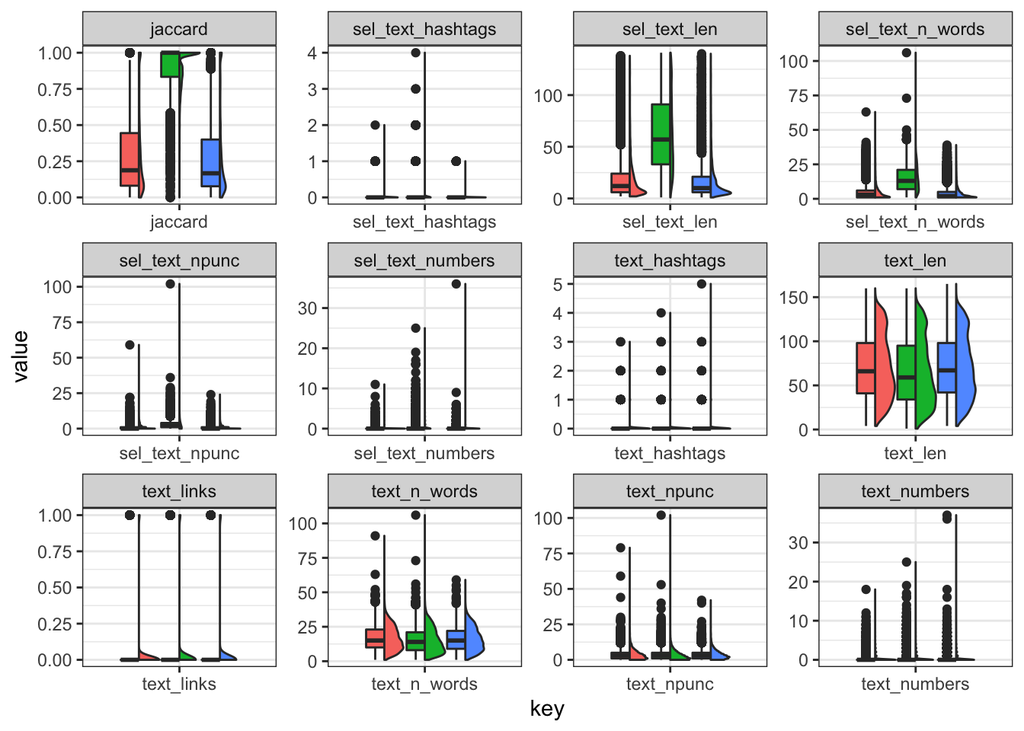

```r
train_metadata %>%
  select(sentiment, jaccard,
         text_len, text_n_words, text_npunc, text_numbers, text_hashtags, text_links,
         sel_text_len, sel_text_n_words, sel_text_npunc, sel_text_numbers, sel_text_hashtags
         ) %>%
  gather(key, value, -sentiment) %>%
  ggplot(aes(x = key, y = value, fill = sentiment))+
  geom_half_boxplot(side = "l", center = TRUE, errorbar.draw = FALSE)+
  geom_half_violin(side = "r")+
  facet_wrap(~key, scales = "free", nrow = 3)+
  theme(legend.position = "botton")
```

Some insights after analyzing the metadata:

- Approximately 75% of texts with neutral sentiment show very high Jaccard similarity, which may indicate that the full text for submission can guarantee a metric around 0.9037 (mean of the jaccard similarity when`sentiment == neutral` in train data);
- The `text_atpeople`,`text_hashtags` `text_links` attributes are not present in most texts;
- The text size (both number of words and characters) is very similar in all cases;
- None of the texts have RT.

Let’s see if some of the metadata attributes are correlated with each other (spearman correlation)

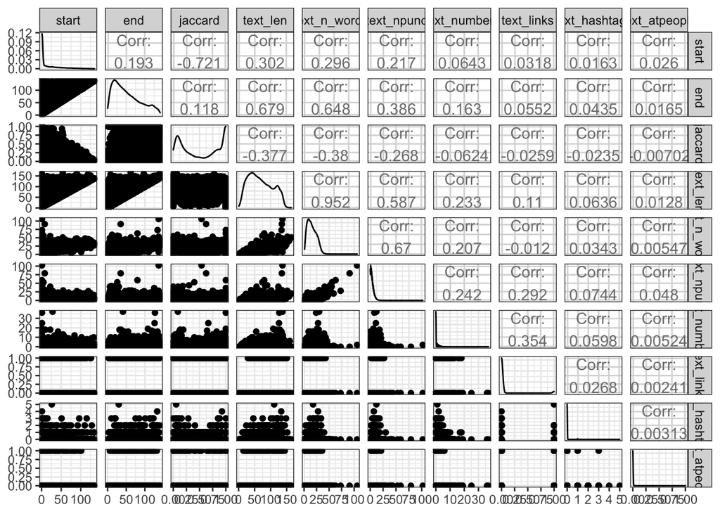

```r
train_metadata %>%
  select(-textID, -text, -sel_text, -sentiment, -text_retweet,
         -text_clean, -text_na, -equal_texts, -starts_with("sel")) %>%
  ggpairs(upper = list(continuous = wrap("cor", method = "spearman")))
```

# Baseline model

Estimated score of jaccard similarity in training data using the full text:

```r
print(glue::glue("Jaccard similarity in training data: {round(mean(train_metadata$jaccard), 4)}"))
```

```
## Jaccard similarity in training data: 0.5475
```

Save the submission file using full `text`column to obtain a reference jaccard metric as starting point for the development of more complex models:

```r
read_csv("data/test.csv") %>%
  select(textID, selected_text = text) %>%
  write_csv("submission.csv")
```

Yeahh!! Lets go submmit!